# Part I - Data Exploration: Communicate Findings via Visualizations

## by Ogbodum, P. Alex

**Table of Contents:**

- Introduction
- Data Wrangling
- Data Storing
- Exploratory Data Analysis (Visualizations)
- Conclusion

## Introduction

> **Name of Dataset: Loan Data From Prosper (.csv):**
> - **Dataset Source:** [Udacity](https://s3.amazonaws.com/udacity-hosted-downloads/ud651/prosperLoanData.csv.)
> - **Description of Dataset:**  
>   This data set contains 113,937 loans with 81 variables on each loan, including loan amount, borrower rate (or interest rate), current loan status, borrower income, and many others.
> - **Variable (Column) Information:**  
>   There are seventeen (81) columns in this data set:
>   1. ListingKey: Unique key for each listing, same value as the 'key' used in the listing object in the API.
>   2. ListingNumber: The number that uniquely identifies the listing to the public as displayed on the website.
>   3. ListingCreationDate: The date the listing was created.
>   4. CreditGrade: The Credit rating that was assigned at the time the listing went live. Applicable for listings pre-2009 period and will only be populated for those listings.
>   5. Term: The length of the loan expressed in months.
>   6. LoanStatus: The current status of the loan: Cancelled, Chargedoff, Completed, Current, Defaulted, FinalPaymentInProgress, PastDue. The PastDue status will be accompanied by a delinquency bucket.
>   7. ClosedDate: Closed date is applicable for Cancelled, Completed, Chargedoff and Defaulted loan statuses.
>   8. BorrowerAPR: The Borrower's Annual Percentage Rate (APR) for the loan. APR is the interest rate for a whole year, rather than just a monthly fee/rate, as applied on a loan. It is a finance charge expressed as an annual rate.
>   9. BorrowerRate: The Borrower's interest rate for this loan.
>   10. LenderYield: The Lender yield on the loan. Lender yield is equal to the interest rate on the loan less the servicing fee.
>   11. EstimatedEffectiveYield: Effective yield is equal to the borrower interest rate (i) minus the servicing fee rate, (ii) minus estimated uncollected interest on charge-offs, (iii) plus estimated collected late fees. Applicable for loans originated after July 2009.
>   12. EstimatedLoss: Estimated loss is the estimated principal loss on charge-offs. Applicable for loans originated after July 2009.
>   13. EstimatedReturn: The estimated return assigned to the listing at the time it was created. Estimated return is the difference between the Estimated Effective Yield and the Estimated Loss Rate. Applicable for loans originated after July 2009.
>   14. ProsperRating (numeric): The Prosper Rating assigned at the time the listing was created: 0 - N/A, 1 - HR, 2 - E, 3 - D, 4 - C, 5 - B, 6 - A, 7 - AA. Applicable for loans originated after July 2009.
>   15. ProsperRating (Alpha): The Prosper Rating assigned at the time the listing was created between AA - HR. Applicable for loans originated after July 2009.
>   16. ProsperScore: A custom risk score built using historical Prosper data. The score ranges from 1-10, with 10 being the best, or lowest risk score. Applicable for loans originated after July 2009.
>   17. ListingCategory: The category of the listing that the borrower selected when posting their listing: 0 - Not Available, 1 - Debt Consolidation, 2 - Home Improvement, 3 - Business, 4 - Personal Loan, 5 - Student Use, 6 - Auto, 7- Other, 8 - Baby&Adoption, 9 - Boat, 10 - Cosmetic Procedure, 11 - Engagement Ring, 12 - Green Loans, 13 - Household Expenses, 14 - Large Purchases, 15 - Medical/Dental, 16 - Motorcycle, 17 - RV, 18 - Taxes, 19 - Vacation, 20 - Wedding Loans.
>   18. BorrowerState: The two letter abbreviation of the state of the address of the borrower at the time the Listing was created.
>   19. Occupation: The Occupation selected by the Borrower at the time they created the listing.
>   20. EmploymentStatus: The employment status of the borrower at the time they posted the listing.
>   21. EmploymentStatusDuration: The length in months of the employment status at the time the listing was created.
>   22. IsBorrowerHomeowner: A Borrower will be classified as a homowner if they have a mortgage on their credit profile or provide documentation confirming they are a homeowner.
>   23. CurrentlyInGroup: Specifies whether or not the Borrower was in a group at the time the listing was created.
>   24. GroupKey: The Key of the group in which the Borrower is a member of. Value will be null if the borrower does not have a group affiliation.
>   25. DateCreditPulled: The date the credit profile was pulled.
>   26. CreditScoreRangeLower: The lower value representing the range of the borrower's credit score as provided by a consumer credit rating agency.
>   27. CreditScoreRangeUpper: The upper value representing the range of the borrower's credit score as provided by a consumer credit rating agency.
>   28. FirstRecordedCreditLine: The date the first credit line was opened.
>   29. CurrentCreditLines: Number of current credit lines at the time the credit profile was pulled.
>   30. OpenCreditLines: Number of open credit lines at the time the credit profile was pulled.
>   31. TotalCreditLinespast7years: Number of credit lines in the past seven years at the time the credit profile was pulled.
>   32. OpenRevolvingAccounts: Number of open revolving accounts at the time the credit profile was pulled.
>   33. OpenRevolvingMonthlyPayment: Monthly payment on revolving accounts at the time the credit profile was pulled.
>   34. InquiriesLast6Months: Number of inquiries in the past six months at the time the credit profile was pulled.
>   35. TotalInquiries: Total number of inquiries at the time the credit profile was pulled.
>   36. CurrentDelinquencies: Number of accounts delinquent at the time the credit profile was pulled.
>   37. AmountDelinquent: Dollars delinquent at the time the credit profile was pulled.
>   38. DelinquenciesLast7Years: Number of delinquencies in the past 7 years at the time the credit profile was pulled.
>   39. PublicRecordsLast10Years: Number of public records in the past 10 years at the time the credit profile was pulled.
>   40. PublicRecordsLast12Months: Number of public records in the past 12 months at the time the credit profile was pulled.
>   41. RevolvingCreditBalance: Dollars of revolving credit at the time the credit profile was pulled.
>   42. BankcardUtilization: The percentage of available revolving credit that is utilized at the time the credit profile was pulled.
>   43. AvailableBankcardCredit: The total available credit via bank card at the time the credit profile was pulled.
>   44. TotalTrades: Number of trade lines ever opened at the time the credit profile was pulled.
>   45. TradesNeverDelinquent: Number of trades that have never been delinquent at the time the credit profile was pulled.
>   46. TradesOpenedLast6Months: Number of trades opened in the last 6 months at the time the credit profile was pulled.
>   47. DebtToIncomeRatio: The debt to income ratio of the borrower at the time the credit profile was pulled. This value is Null if the debt to income ratio is not available. This value is capped at 10.01 (any debt to income ratio larger than 1000% will be returned as 1001%).
>   48. IncomeRange: The income range of the borrower at the time the listing was created.
>   49. IncomeVerifiable: The borrower indicated they have the required documentation to support their income.
>   50. StatedMonthlyIncome: The monthly income the borrower stated at the time the listing was created.
>   51. LoanKey: Unique key for each loan. This is the same key that is used in the API.
>   52. TotalProsperLoans: Number of Prosper loans the borrower at the time they created this listing. This value will be null if the borrower had no prior loans.
>   53. TotalProsperPaymentsBilled: Number of on time payments the borrower made on Prosper loans at the time they created this listing. This value will be null if the borrower had no prior loans.
>   54. OnTimeProsperPayments: Number of on time payments the borrower had made on Prosper loans at the time they created this listing. This value will be null if the borrower has no prior loans.
>   55. ProsperPaymentsLessThanOneMonthLate: Number of payments the borrower made on Prosper loans that were less than one month late at the time they created this listing. This value will be null if the borrower had no prior loans.
>   56. ProsperPaymentsOneMonthPlusLate: Number of payments the borrower made on Prosper loans that were greater than one month late at the time they created this listing. This value will be null if the borrower had no prior loans.
>   57. ProsperPrincipalBorrowed: Total principal borrowed on Prosper loans at the time the listing was created. This value will be null if the borrower had no prior loans.
>   58. ProsperPrincipalOutstanding: Principal outstanding on Prosper loans at the time the listing was created. This value will be null if the borrower had no prior loans.
>   59. ScorexChangeAtTimeOfListing: Borrower's credit score change at the time the credit profile was pulled. This will be the change relative to the borrower's last Prosper loan. This value will be null if the borrower had no prior loans.
>   60. LoanCurrentDaysDelinquent: The number of days delinquent.
>   61. LoanFirstDefaultedCycleNumber: The cycle the loan was charged off. If the loan has not charged off the value will be null.
>   62. LoanMonthsSinceOrigination: Number of months since the loan originated.
>   63. LoanNumber: Unique numeric value associated with the loan.
>   64. LoanOriginalAmount: The origination amount of the loan.
>   65. LoanOriginationDate: The date the loan was originated.
>   66. LoanOriginationQuarter: The quarter in which the loan was originated.
>   67. MemberKey: The unique key that is associated with the borrower. This is the same identifier that is used in the API member object.
>   68. MonthlyLoanPayment: The scheduled monthly loan payment.
>   69. LP_CustomerPayments: Pre charge-off cumulative gross payments made by the borrower on the loan. If the loan has charged off, this value will exclude any recoveries.
>   70. LP_CustomerPrincipalPayments: Pre charge-off cumulative principal payments made by the borrower on the loan. If the loan has charged off, this value will exclude any recoveries.
>   71. LP_InterestandFees: Pre charge-off cumulative interest and fees paid by the borrower. If the loan has charged off, this value will exclude any recoveries.
>   72. LP_ServiceFees: Cumulative service fees paid by the investors who have invested in the loan.
>   73. LP_CollectionFees: Cumulative collection fees paid by the investors who have invested in the loan.
>   74. LP_GrossPrincipalLoss: The gross charged off amount of the loan.
>   75. LP_NetPrincipalLoss: The principal that remains uncollected after any recoveries.
>   76. LP_NonPrincipalRecoverypayments: The interest and fee component of any recovery payments. The current payment policy applies payments in the following order: Fees, interest, principal.
>   77. PercentFunded: Percent the listing was funded.
>   78. Recommendations: Number of recommendations the borrower had at the time the listing was created.
>   79. InvestmentFromFriendsCount: Number of friends that made an investment in the loan.
>   80. InvestmentFromFriendsAmount: Dollar amount of investments that were made by friends.
>   81. Investors: The number of investors that funded the loan.

**Analysis Question:**

- Who were the top borrowers and what was/were some of their unique characteristics?

## Data Wrangling

```python
# import all packages and set plots to be embedded inline
import numpy as np
import pandas as pd
import matplotlib.pyplot as plt
import seaborn as sb
import requests as rq

%matplotlib inline
```

```python
# global setting to see all column names with .head()
pd.set_option('display.max_columns', None)
pd.set_option('display.max_rows', None) # for rows
```

```python
# set fontsize globally
font_size = 12
plt.rc('font', size=font_size)
plt.rc('axes', titlesize=font_size)
```

### Data Gathering

**Download data set programmatically**

```python
# file download link
url = "https://s3.amazonaws.com/udacity-hosted-downloads/ud651/prosperLoanData.csv"

# the statements below were commented out to avoid error due to file already in existence in directory
# request file
# file = rq.get(url)

# write received file to csv
# with open('prosperloan.csv', 'wb') as csv:
    # csv.write(file.content)

# read csv as dataframe
loandata = pd.read_csv('prosperloan.csv')

# preview 10 random rows
loandata.sample(n=2)
```

|  | ListingKey | ListingNumber | ListingCreationDate | CreditGrade | Term | LoanStatus | ClosedDate | BorrowerAPR | BorrowerRate | LenderYield | EstimatedEffectiveYield | EstimatedLoss | EstimatedReturn | ProsperRating (numeric) | ProsperRating (Alpha) | ProsperScore | ListingCategory (numeric) | BorrowerState | Occupation | EmploymentStatus | EmploymentStatusDuration | IsBorrowerHomeowner | CurrentlyInGroup | GroupKey | DateCreditPulled | CreditScoreRangeLower | CreditScoreRangeUpper | FirstRecordedCreditLine | CurrentCreditLines | … |
| --- | --- | --- | --- | --- | --- | --- | --- | --- | --- | --- | --- | --- | --- | --- | --- | --- | --- | --- | --- | --- | --- | --- | --- | --- | --- | --- | --- | --- | --- | --- |
| 94879 | 22F0347520052927624E0B4 | 445365 | 2010-02-03 10:47:24.640000000 | NaN | 36 | Chargedoff | 2012-01-17 00:00:00 | 0.37453 | 0.3500 | 0.3400 | 0.13990 | 0.1800 | 0.13990 | 1.0 | HR | 4.0 | 3 | NC | Other | Full-time | 1.0 | False | False | NaN | 2010-02-03 10:25:04 | 640.0 | 659.0 | 1994-05-26 00:00:00 | 4.0 | … |
| 19127 | 6CA1359646813642599A838 | 1076471 | 2013-12-14 13:52:10.403000000 | NaN | 36 | Current | NaN | 0.16732 | 0.1314 | 0.1214 | 0.11567 | 0.0449 | 0.07077 | 5.0 | B | 7.0 | 1 | OR | Other | Employed | 58.0 | True | False | NaN | 2013-12-14 13:52:12 | 720.0 | 739.0 | 1990-11-27 00:00:00 | 8.0 | … |

- There are 113937 rows, and 81 columns in the dataframe.

### Data Assessment

For this analysis, I will be focusing on those variables associated with my analysis questions. As a result I create a sub-dataframe containing only those variable.

```python
# create sub-dataframe
df = loandata[['ListingKey', 'Occupation', 'DebtToIncomeRatio', 'CurrentlyInGroup', 'GroupKey', 'ScorexChangeAtTimeOfListing',
 'Recommendations', 'BorrowerState', 'EmploymentStatus', 'EmploymentStatusDuration', 'LoanStatus',
 'ListingCategory (numeric)', 'StatedMonthlyIncome', 'IncomeVerifiable', 'IncomeRange', 'ListingCreationDate']]

# preview
df.sample(n=3)
```

|  | ListingKey | Occupation | DebtToIncomeRatio | CurrentlyInGroup | GroupKey | ScorexChangeAtTimeOfListing | Recommendations | BorrowerState | EmploymentStatus | EmploymentStatusDuration | LoanStatus | ListingCategory (numeric) | StatedMonthlyIncome | IncomeVerifiable | IncomeRange | ListingCreationDate |
| --- | --- | --- | --- | --- | --- | --- | --- | --- | --- | --- | --- | --- | --- | --- | --- | --- |
| 7884 | 021833695370102620B5B03 | Skilled Labor | 0.21 | True | 6A3B336601725506917317E | NaN | 0 | WV | Not available | NaN | Defaulted | 0 | 1950.000000 | True | Not displayed | 2006-10-06 10:05:29.663000000 |
| 41259 | 571D35573935153896A4E66 | Sales - Commission | 0.20 | False | NaN | -29.0 | 0 | TX | Employed | 25.0 | Current | 1 | 7666.666667 | True | $75,000-99,999 | 2012-09-04 10:31:26.540000000 |
| 70206 | C16435825544550726C7F24 | Other | 0.53 | False | NaN | NaN | 0 | GA | Other | 302.0 | Current | 1 | 1322.000000 | True | $1-24,999 | 2013-06-18 11:05:08.183000000 |

- column name with space (ListingCategory (numeric)) needs to be renamed. [quality issue]

```python
# dimension of dataframe
df.shape
```

```
(113937, 16)
```

- There are now 113,937 rows and 16 columns in the dataframe. As oppose to 113,937 rows and 81 columns in the original data set.

```python
# dataframe overview
df.info()
```

```
<class 'pandas.core.frame.DataFrame'>
RangeIndex: 113937 entries, 0 to 113936
Data columns (total 16 columns):
 #   Column                       Non-Null Count   Dtype
---  ------                       --------------   -----
 0   ListingKey                   113937 non-null  object
 1   Occupation                   110349 non-null  object
 2   DebtToIncomeRatio            105383 non-null  float64
 3   CurrentlyInGroup             113937 non-null  bool
 4   GroupKey                     13341 non-null   object
 5   ScorexChangeAtTimeOfListing  18928 non-null   float64
 6   Recommendations              113937 non-null  int64
 7   BorrowerState                108422 non-null  object
 8   EmploymentStatus             111682 non-null  object
 9   EmploymentStatusDuration     106312 non-null  float64
 10  LoanStatus                   113937 non-null  object
 11  ListingCategory (numeric)    113937 non-null  int64
 12  StatedMonthlyIncome          113937 non-null  float64
 13  IncomeVerifiable             113937 non-null  bool
 14  IncomeRange                  113937 non-null  object
 15  ListingCreationDate          113937 non-null  object
dtypes: bool(2), float64(4), int64(2), object(8)
memory usage: 12.4+ MB
```

- Data type for ListingCreationDate needs to be changed to datetime as it contains date series values. [quality issue]
- Several columns have missing values. [tidiness issue]

```python
# check duplicates
df.duplicated().any()
```

```
True
```

- There exist duplicate rows in the dataframe. [tidiness issue]

```python
# check number of duplicates
df.duplicated().sum()
```

```
871
```

- There are 871 duplicated rows.

```python
# re-confirm there are any missing value
df.isna().sum().any()
```

```
True
```

```python
# see columns alongside count of missing values
df.isna().sum()
```

```
ListingKey                          0
Occupation                       3588
DebtToIncomeRatio                8554
CurrentlyInGroup                    0
GroupKey                       100596
ScorexChangeAtTimeOfListing     95009
Recommendations                     0
BorrowerState                    5515
EmploymentStatus                 2255
EmploymentStatusDuration         7625
LoanStatus                          0
ListingCategory (numeric)           0
StatedMonthlyIncome                 0
IncomeVerifiable                    0
IncomeRange                         0
ListingCreationDate                 0
dtype: int64
```

- Columns - Occupation, DebtToIncomeRatio, GroupKey, ScorexChangeAtTimeOfListing, BorrowerState, EmploymentStatus, and EmploymentStatusDuration all have missing values

```python
# total number of missing values
df.isnull().values.sum()
```

```
223142
```

- About 12% of values are missing from the dataframe. 223,142 to be precise.

```python
# summary statistics
df.describe()
```

|  | DebtToIncomeRatio | ScorexChangeAtTimeOfListing | Recommendations | EmploymentStatusDuration | ListingCategory (numeric) | StatedMonthlyIncome |
| --- | --- | --- | --- | --- | --- | --- |
| count | 105383.000000 | 18928.000000 | 113937.000000 | 106312.000000 | 113937.000000 | 1.139370e+05 |
| mean | 0.275947 | -3.223214 | 0.048027 | 96.071582 | 2.774209 | 5.608026e+03 |
| std | 0.551759 | 50.063567 | 0.332353 | 94.480605 | 3.996797 | 7.478497e+03 |
| min | 0.000000 | -209.000000 | 0.000000 | 0.000000 | 0.000000 | 0.000000e+00 |
| 25% | 0.140000 | -35.000000 | 0.000000 | 26.000000 | 1.000000 | 3.200333e+03 |
| 50% | 0.220000 | -3.000000 | 0.000000 | 67.000000 | 1.000000 | 4.666667e+03 |
| 75% | 0.320000 | 25.000000 | 0.000000 | 137.000000 | 3.000000 | 6.825000e+03 |
| max | 10.010000 | 286.000000 | 39.000000 | 755.000000 | 20.000000 | 1.750003e+06 |

**Rationale:**

- Having recommendations doesn't seem to have an effect in getting the loan funded.
- Over 50% of those who got the loan had a debt-to-income ratio of less than 30%.
- The majority of borrowers had at least 5 years of work experience.
- Borrowers in general had monthly income above $1000.

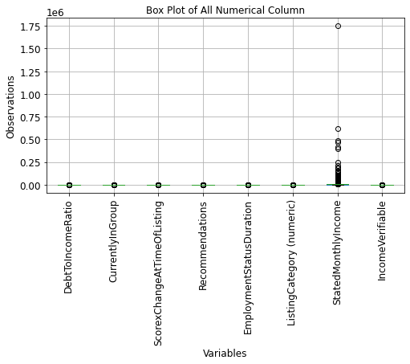

```python
# check for outliers using boxplot

def bxxplot(dff):
    bxplot = dff.boxplot(figsize=(8,4), fontsize=(12));
    bxplot.set_ylabel('Observations');
    bxplot.set_xlabel('Variables');
    bxplot.set_title('Box Plot of All Numerical Column');
    plt.xticks(rotation=90);

bxxplot(df)
```

- Outliers exist in the StatedMonthlyIncome column

[output not shown]

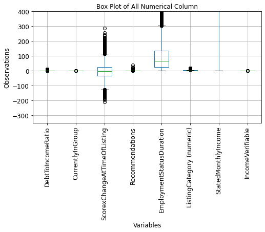

```python
# plot the box blot with different ylim to zoom in at several levels for more details and clarity
print(bxxplot(df));
plt.ylim(-350, 400);
```

```
None
```

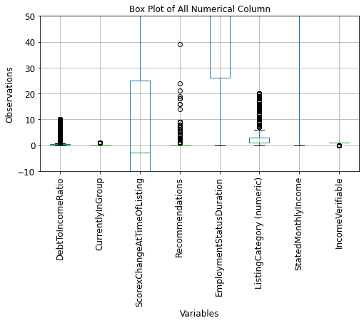

```python
print(bxxplot(df));
plt.ylim(-10, 50);
```

- There seem to exist outliers in every column. However, these are not issues that will affect our analysis as they are contextually correct. But values greater than than 10.00 for DebtToIncomeRatio will be replaced with 10.00. As this is the max threshold.

**Summary:**

- column: ListingCategory (numeric), needs to be renamed. [quality issue]
- Data type for ListingCreationDate needs to be changed to datetime as it contains date series values. [quality issue]
- There exist duplicate rows in the dataframe. [tidiness issue]
- Columns - Occupation, DebtToIncomeRatio, GroupKey, ScorexChangeAtTimeOfListing, BorrowerState, EmploymentStatus, and EmploymentStatusDuration all have missing values. [tidiness issue].
- Outliers in DebtToIncomeRatio column. [quality issue]

### Data Cleaning

**Define:**

1. Rename ListingCategory (numeric), to ListingCategory
2. Change ListingCreationDate data type from object(string) to datatime.
3. Drop duplicate rows.
4. Fix missing values in the following columns (Occupation, DebtToIncomeRatio, GroupKey, ScorexChangeAtTimeOfListing, BorrowerState, EmploymentStatus, and EmploymentStatusDuration).
5. Assign values greater than 10.00 in DebtToIncomeRatio column to 10.00.

**Code:**

```python
# create duplicate for safe keeping
dff = df.copy()
```

1. Rename ListingCategory (numeric), to ListingCategory

```python
# rename cumbersome column name
dff = dff.rename(columns={'ListingCategory (numeric)':'ListingCategory'})
```

1. Change ListingCreationDate data type from object(string) to datatime.

```python
# change column type to datetime
dff.ListingCreationDate = pd.to_datetime(dff.ListingCreationDate);
```

1. Drop duplicate rows.

```python
# drop duplicates
dff = dff.drop_duplicates()
```

1. Fix missing values in the following columns (Occupation, DebtToIncomeRatio, GroupKey, ScorexChangeAtTimeOfListing, BorrowerState, EmploymentStatus, and EmploymentStatusDuration).

```python
# Create function to replace missing value
def re_assign(dataframe, column, val):
    dataframe.loc[dataframe[column].isna(), column] = val

re_assign(dff, 'Occupation', 'Other')
re_assign(dff, 'DebtToIncomeRatio', 0)
re_assign(dff, 'GroupKey', 'No affiliation')
re_assign(dff, 'ScorexChangeAtTimeOfListing', 0)
re_assign(dff, 'BorrowerState', 'NA')
re_assign(dff, 'EmploymentStatus', 'Not Available')
re_assign(dff, 'EmploymentStatusDuration', 0)
```

1. Assign values greater than 10.00 in DebtToIncomeRatio column to 10.00.

```python
# Assign values greater than 10.00 in DebtToIncomeRatio column to 10.00.
dff.loc[dff.DebtToIncomeRatio > 10.00, 'DebtToIncomeRatio'] = 10.00
```

**Test:**

```python
# 1. Check column names
dff.columns
```

```
Index(['ListingKey', 'Occupation', 'DebtToIncomeRatio', 'CurrentlyInGroup',
       'GroupKey', 'ScorexChangeAtTimeOfListing', 'Recommendations',
       'BorrowerState', 'EmploymentStatus', 'EmploymentStatusDuration',
       'LoanStatus', 'ListingCategory', 'StatedMonthlyIncome',
       'IncomeVerifiable', 'IncomeRange', 'ListingCreationDate'],
      dtype='object')
```

```python
# 2. Check datatypes for columns
dff.dtypes
```

```
ListingKey                             object
Occupation                             object
DebtToIncomeRatio                     float64
CurrentlyInGroup                         bool
GroupKey                               object
ScorexChangeAtTimeOfListing           float64
Recommendations                         int64
BorrowerState                          object
EmploymentStatus                       object
EmploymentStatusDuration              float64
LoanStatus                             object
ListingCategory                         int64
StatedMonthlyIncome                   float64
IncomeVerifiable                         bool
IncomeRange                            object
ListingCreationDate            datetime64[ns]
dtype: object
```

```python
# 3. check for duplicates
dff.duplicated().any()
```

```
False
```

```python
# 4. check for missing values
dff.isna().sum().any()
```

```
False
```

```python
# 5. check that no value is greater than 10.00 in DebtToIncomeRatio column
dff.DebtToIncomeRatio.describe()
```

```
count    113066.000000
mean          0.255325
std           0.537087
min           0.000000
25%           0.120000
50%           0.210000
75%           0.310000
max          10.000000
Name: DebtToIncomeRatio, dtype: float64
```

```python
dff.shape
```

```
(113066, 16)
```

### What is the structure of your dataset?

> The dataframe consist of 113,066 rows and 16 columns (variables)

### What is/are the main feature(s) of interest in your dataset?

> **The following columns/variables will be of interest for my analysis:**
> - Occupation
> - DebtToIncomeRatio
> - CurrentlyInGroup
> - GroupKey
> - ScorexChangeAtTimeOfListing
> - Recommendations
> - BorrowerState
> - EmploymentStatus
> - EmploymentStatusDuration
> - LoanStatus
> - ListingCategory
> - StatedMonthlyIncome
> - IncomeVerifiable
> - IncomeRange
> - ListingCreationDate

### What features in the dataset do you think will help support your investigation into your feature(s) of interest?

> The data types of the variables, frequency, and correlation

## Data Storing

```python
# export cleaned dataframe as CSV file
# dff.to_csv('prosperloan_cleaned.csv')
```

## Exploratory Data Analysis

## Univariate Exploration

#### Question

- Which occupation had the most listings?

  > Because the list of unique values for the occupation variable are many and will create clustering when plotted all together, I will plot top 10 and last 10 occupation relative to the amount of loans.

#### Visualization

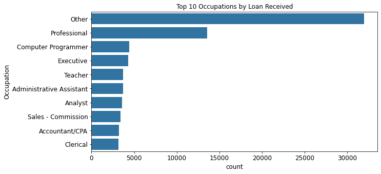

```python
# round StatedMonthlyIncome column values to whole numbers
dff['StatedMonthlyIncome'] = np.round(dff['StatedMonthlyIncome']).apply(np.int64)

# Top 10 occupation that received loans
occ_color = sb.color_palette()[0]
occ_order = dff.Occupation.value_counts().index
plt.figure(figsize=(10,5))
sb.countplot(data=dff, y='Occupation', color=occ_color, order=occ_order[:10]).set(title='Top 10 Occupations by Loan Received');
```

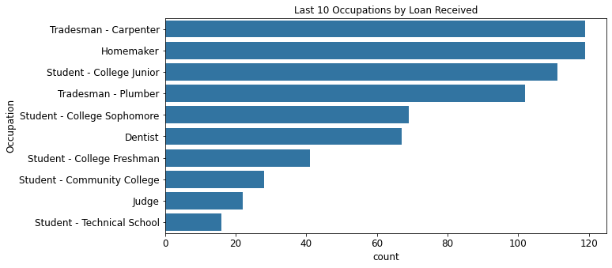

```python
# Last 10 occupation that received loans
plt.figure(figsize=(10,5))
sb.countplot(data=dff, y='Occupation',
             color=occ_color,
             order=occ_order[-10:]).set(title='Last 10 Occupations by Loan Received');
```

#### Question

Around what time (year) were those listings made generally?

```python
dff.head()
```

|  | ListingKey | Occupation | DebtToIncomeRatio | CurrentlyInGroup | GroupKey | ScorexChangeAtTimeOfListing | Recommendations | BorrowerState | EmploymentStatus | EmploymentStatusDuration | LoanStatus | ListingCategory | StatedMonthlyIncome | IncomeVerifiable | IncomeRange | ListingCreationDate |
| --- | --- | --- | --- | --- | --- | --- | --- | --- | --- | --- | --- | --- | --- | --- | --- | --- |
| 0 | 1021339766868145413AB3B | Other | 0.17 | True | No affiliation | 0.0 | 0 | CO | Self-employed | 2.0 | Completed | 0 | 3083 | True | $25,000-49,999 | 2007-08-26 19:09:29.263 |
| 1 | 10273602499503308B223C1 | Professional | 0.18 | False | No affiliation | 0.0 | 0 | CO | Employed | 44.0 | Current | 2 | 6125 | True | $50,000-74,999 | 2014-02-27 08:28:07.900 |
| 2 | 0EE9337825851032864889A | Other | 0.06 | True | 783C3371218786870A73D20 | 0.0 | 0 | GA | Not available | 0.0 | Completed | 0 | 2083 | True | Not displayed | 2007-01-05 15:00:47.090 |
| 3 | 0EF5356002482715299901A | Skilled Labor | 0.15 | False | No affiliation | 0.0 | 0 | GA | Employed | 113.0 | Current | 16 | 2875 | True | $25,000-49,999 | 2012-10-22 11:02:35.010 |
| 4 | 0F023589499656230C5E3E2 | Executive | 0.26 | False | No affiliation | 0.0 | 0 | MN | Employed | 44.0 | Current | 2 | 9583 | True | $100,000+ | 2013-09-14 18:38:39.097 |

#### Visualization

```python
# create sub-dataframe of to 10 occupation
occ_top = dff[(dff.Occupation == 'Other') |
              (dff.Occupation == 'Professional') |
             (dff.Occupation == 'Computer Programmer') |
             (dff.Occupation == 'Executive') |
             (dff.Occupation == 'Teacher') |
             (dff.Occupation == 'Administrative Assistant') |
             (dff.Occupation == 'Analyst') |
             (dff.Occupation == 'Sales - Commission') |
             (dff.Occupation == 'Accountant/CPA') |
             (dff.Occupation == 'Clerical')
             ]

# get the frequency for each year
occ_vcount = occ_top.ListingCreationDate.dt.year.value_counts()

# get the minimum count relative to year.
occ_vcount.min()
```

```
23
```

[figure not shown]

```python
# make histogram plot
fig, ax = plt.subplots(4, figsize=(15, 10));
fig.suptitle('Distribution of Funded Loans Across Several Years')
ax[0].hist(data=occ_top, x='ListingCreationDate');
ax[1].hist(data=occ_top, x='ListingCreationDate', bins = 15);
ax[2].hist(data=occ_top, x='ListingCreationDate', bins = 22);
ax[3].hist(data=occ_top, x='ListingCreationDate', bins = 30);

# plot axis labels
fig.supxlabel('Frequency');
fig.supylabel('Years of Loan Funding');
```

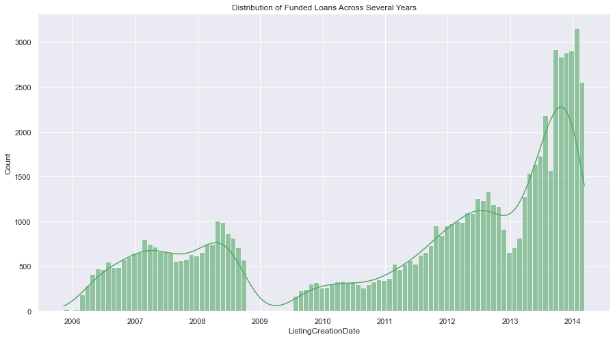

```python
# seaborn distribution plot
sb.set(rc = {'figure.figsize':(15,8)}) # change figure size
sb.histplot(occ_top['ListingCreationDate'], kde=True, alpha=.6,
            bins = 100,
           color = 'g').set(title='Distribution of Funded Loans Across Several Years');
```

#### Observation

- From 2006 to 2014, there was drought in loan funding in the year 2009. Then from 2011, there was an uptrend which experienced an initial slight dip in 2013 before moving upwards to an all time high through to 2014.

#### Question

In what year did computer programmers get the most funding?

#### Visualization

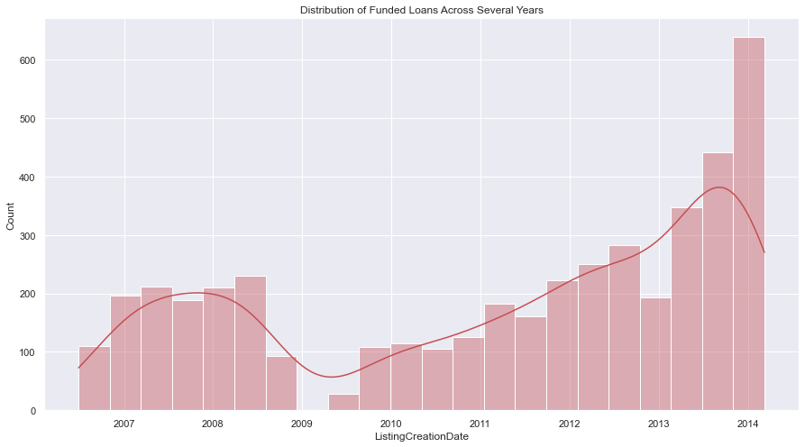

```python
# create a sub-dataframe for the computer programmers and professionals
occ_comp = dff[dff.Occupation == 'Computer Programmer']

# plot a histogram
sb.histplot(occ_comp['ListingCreationDate'],
            kde=True, alpha=.4,
            bins = 22,
           color='r').set(title='Distribution of Funded Loans Across Several Years');
```

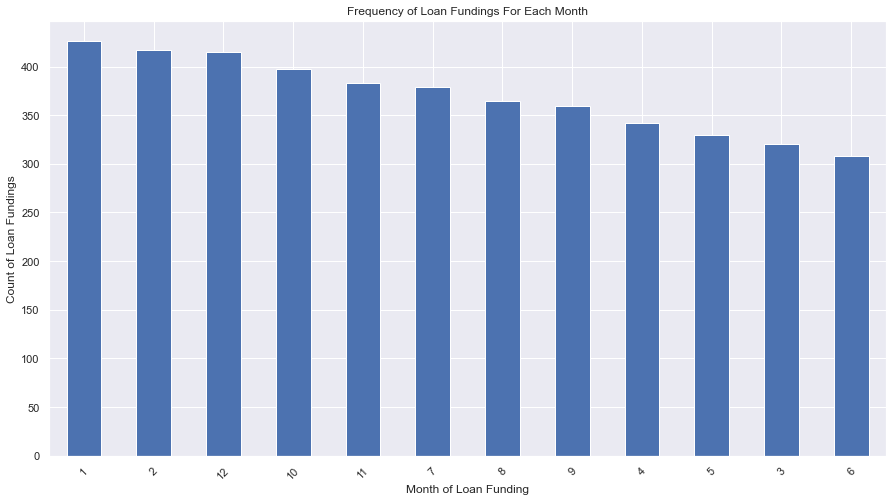

```python
# bar plot of frequency vs loan funding per month
occ_comp['ListingCreationDate'].dt.month.value_counts().plot(kind='bar',
                                                             title = 'Frequency of Loan Fundings For Each Month',
                                                            xlabel = 'Month of Loan Funding',
                                                            ylabel = 'Count of Loan Fundings',
                                                             rot=45);
```

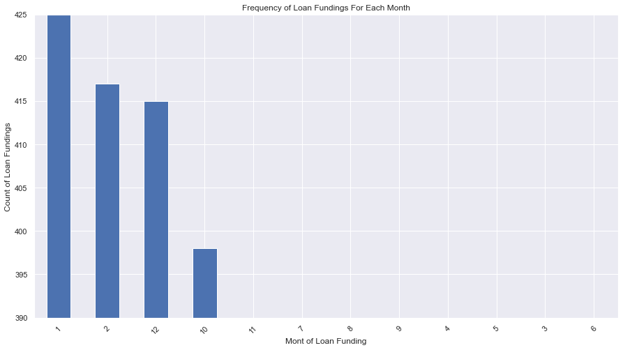

```python
# bar plot
occ_comp['ListingCreationDate'].dt.month.value_counts().plot(kind='bar',
                                                             title = 'Frequency of Loan Fundings For Each Month',
                                                            xlabel = 'Mont of Loan Funding',
                                                            ylabel = 'Count of Loan Fundings',
                                                             rot=45);
plt.ylim((390,425)); # zoom on the y-axis
```

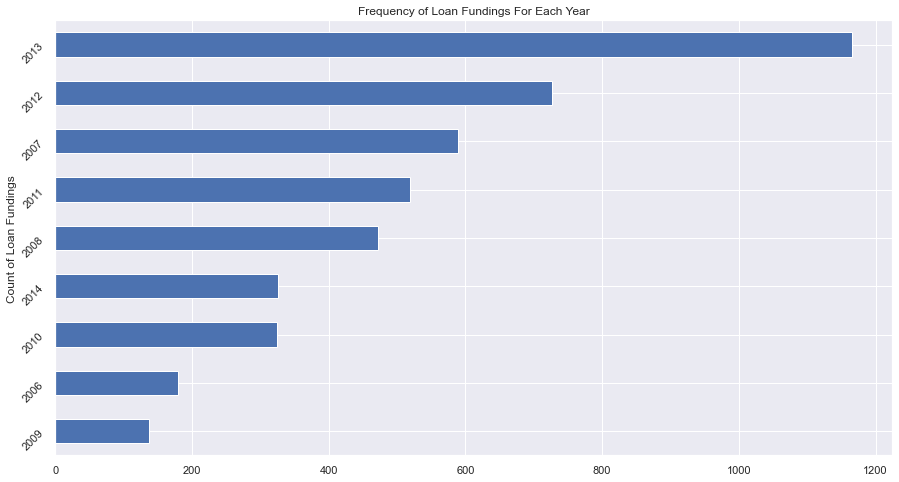

```python
# horizontal bar plot of yearly funding frequency
occ_comp['ListingCreationDate'].dt.year.value_counts(ascending=True).plot(kind='barh',
                                                            title = 'Frequency of Loan Fundings For Each Year',
                                                            ylabel = 'Count of Loan Fundings',
                                                            rot=45);
```

#### Question

- What was the average income of these individuals at the time they made their listings? (IncomeRange, IncomeVerifiable, StatedMonthlyIncome)

```python
# preview specific columns
occ_comp.loc[:,['StatedMonthlyIncome', 'IncomeVerifiable', 'IncomeRange']].sample(n=2)
```

|  | StatedMonthlyIncome | IncomeVerifiable | IncomeRange |
| --- | --- | --- | --- |
| 7327 | 8000 | True | $75,000-99,999 |
| 37103 | 8833 | True | $100,000+ |

- We need to do a bit of wrangling - Ensure 'IncomeVerifiable' is true, and skip 'not displayed' for 'IncomeRange'

```python
# create sub-dataframe for computer programmers to filter based on specific parameter
comp_income = occ_comp[(occ_comp['IncomeVerifiable'] == True)
                        & (occ_comp['IncomeRange'] != 'Not displayed')]

# test result
comp_income.loc[:, ['StatedMonthlyIncome', 'IncomeRange', 'IncomeVerifiable']].sample(n=2)
```

|  | StatedMonthlyIncome | IncomeRange | IncomeVerifiable |
| --- | --- | --- | --- |
| 13832 | 5407 | $50,000-74,999 | True |
| 59720 | 7107 | $75,000-99,999 | True |

```python
# assess descriptive statistics of column
comp_income.StatedMonthlyIncome.describe()
```

```
count     3956.000000
mean      7258.577098
std       2896.404034
min          0.000000
25%       5417.000000
50%       7000.000000
75%       8750.000000
max      52500.000000
Name: StatedMonthlyIncome, dtype: float64
```

#### Visualization

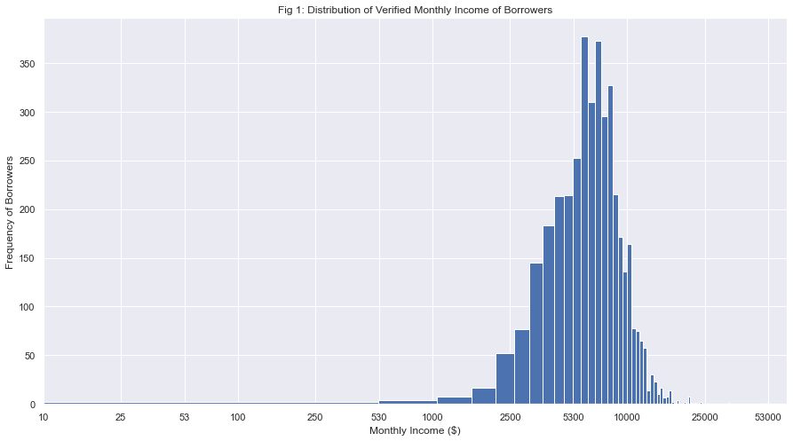

```python
# plot histogram to show distribution of monthly income earned
plt.hist(comp_income['StatedMonthlyIncome'], bins=100);
ticks = [10, 25, 53, 100, 250, 530, 1000, 2500, 5300, 10000, 25000, 53000];
labels = ['{}'.format(val) for val in ticks];
plt.xscale('log');
plt.xticks(ticks, labels);
plt.title('Fig 1: Distribution of Verified Monthly Income of Borrowers');
plt.xlabel('Monthly Income ($)');
plt.ylabel('Frequency of Borrowers');
```

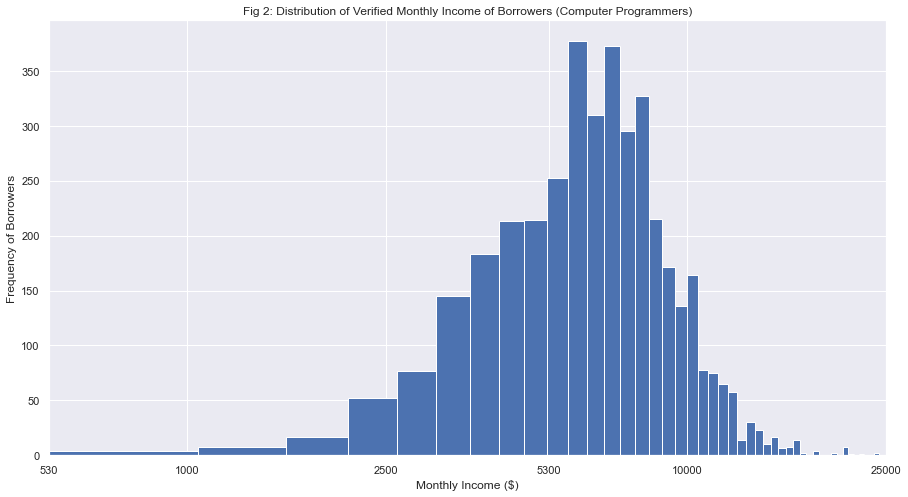

```python
# to zoom in for a better view
plt.hist(comp_income['StatedMonthlyIncome'], bins=100);
ticks = [10, 25, 53, 100, 250, 530, 1000, 2500, 5300, 10000, 25000, 53000];
labels = ['{}'.format(val) for val in ticks];
plt.xscale('log');
plt.xticks(ticks, labels);
plt.title('Fig 2: Distribution of Verified Monthly Income of Borrowers (Computer Programmers)');
plt.xlabel('Monthly Income ($)');
plt.ylabel('Frequency of Borrowers');
plt.xlim((530,25000));
```

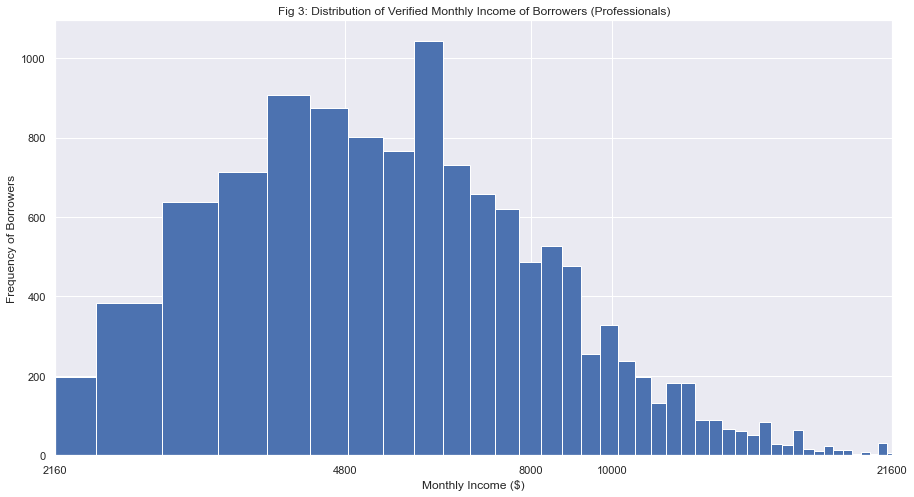

```python
# create sub-dataframe for Professional
pro_income = dff[
    (dff['Occupation']=='Professional') &
    (dff['IncomeVerifiable'] == True) &
    (dff['IncomeRange'] != 'Not displayed')
]

# create histogram plot for professionals monthly income
plt.hist(pro_income['StatedMonthlyIncome'],bins=1000);
ticks = [200, 480, 800, 1000, 2160, 4800, 8000, 10000, 21600, 48000, 216000, 480000];
labels = ['{}'.format(val) for val in ticks];
plt.xscale('log');
plt.xticks(ticks, labels);
plt.title('Fig 3: Distribution of Verified Monthly Income of Borrowers (Professionals)');
plt.xlabel('Monthly Income ($)');
plt.ylabel('Frequency of Borrowers');
plt.xlim((2160,21600));
```

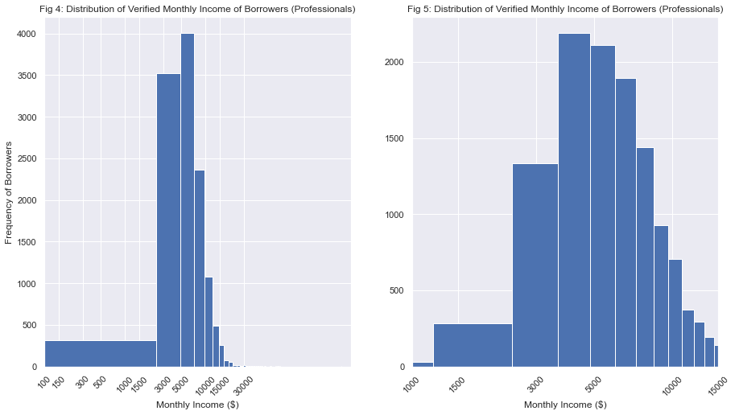

```python
# create sub-plots with different bin values
# sub-plot with bin size = 200
axa = plt.subplot(1, 2, 1)
plt.hist(data=pro_income, x='StatedMonthlyIncome', bins=200);
ticks = [100, 150, 300, 500, 1000, 1500, 3000, 5000, 10000, 15000, 30000]
labels = ['{}'.format(val) for val in ticks];
plt.xscale('log');
plt.xticks(ticks, labels, rotation = 45);
plt.title('Fig 4: Distribution of Verified Monthly Income of Borrowers (Professionals)');
plt.xlabel('Monthly Income ($)');
plt.ylabel('Frequency of Borrowers');

# sub-plot 2 with bin size = 400
axa = plt.subplot(1, 2, 2)
plt.hist(data=pro_income, x='StatedMonthlyIncome', bins = 400);
ticks = [100, 150, 300, 500, 1000, 1500, 3000, 5000, 10000, 15000, 30000]
labels = ['{}'.format(val) for val in ticks];
plt.xscale('log');
plt.xticks(ticks, labels, rotation = 45);
plt.title('Fig 5: Distribution of Verified Monthly Income of Borrowers (Professionals)');
plt.xlabel('Monthly Income ($)');
plt.xlim((1000,15000));
```

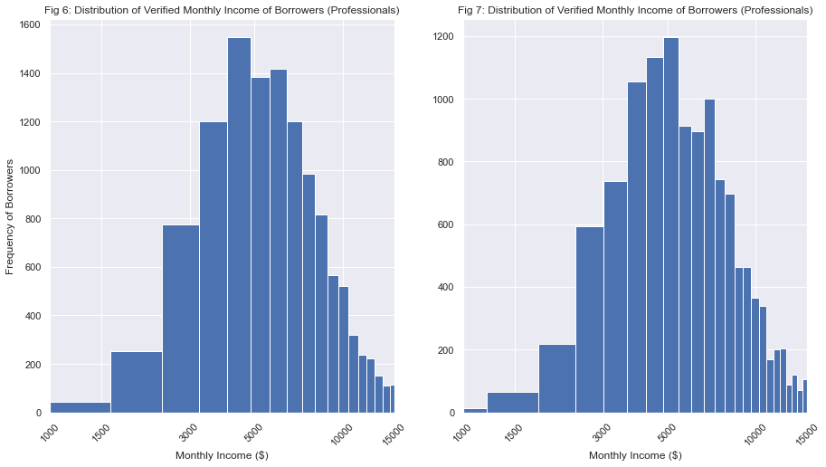

```python
# sub-plot 2 with bin size = 600
axa = plt.subplot(1, 2, 1)
plt.hist(data=pro_income, x='StatedMonthlyIncome', bins=600);
ticks = [100, 150, 300, 500, 1000, 1500, 3000, 5000, 10000, 15000, 30000]
labels = ['{}'.format(val) for val in ticks];
plt.xscale('log');
plt.xticks(ticks, labels, rotation = 45);
plt.title('Fig 6: Distribution of Verified Monthly Income of Borrowers (Professionals)');
plt.xlabel('Monthly Income ($)');
plt.ylabel('Frequency of Borrowers');
plt.xlim((1000,15000));

# sub-plot 2 with bin size = 800
axa = plt.subplot(1, 2, 2)
plt.hist(data=pro_income, x='StatedMonthlyIncome', bins = 800);
ticks = [100, 150, 300, 500, 1000, 1500, 3000, 5000, 10000, 15000, 30000]
labels = ['{}'.format(val) for val in ticks];
plt.xscale('log');
plt.xticks(ticks, labels, rotation = 45);
plt.title('Fig 7: Distribution of Verified Monthly Income of Borrowers (Professionals)');
plt.xlabel('Monthly Income ($)');
plt.xlim((1000,15000));
```

The professional category in general seem to have an average monthly income of about USD5000, which is the minimum value of computer programmers average monthly income range.

```
            Fig 8: A Plot of Frequency (y-axis) vs Monthly Income (USD) for top 5 Known Occupation Category
```

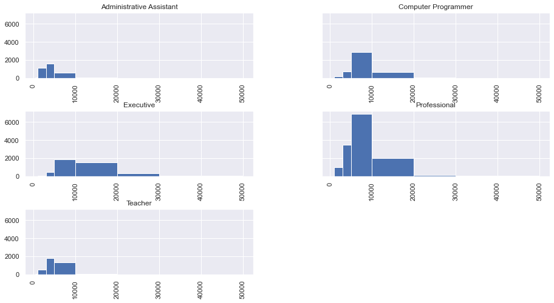

```python
# top 5 know occupation
Top_Occ = dff[
        (dff['Occupation'] == 'Professional') |
        (dff['Occupation'] == 'Executive') |
        (dff['Occupation'] == 'Computer Programmer') |
        (dff['Occupation'] == 'Teacher') |
        (dff['Occupation'] == 'Administrative Assistant') &
        (dff['IncomeVerifiable'] == True) &
        (dff['IncomeRange'] != 'Not displayed')
             ]
# string to use as title
x = 'Fig 8: A Plot of Frequency (y-axis) vs Monthly Income (USD) for top 5 Known Occupation Category'
print(x.center(120))

# histogram plot for top 5 occupation category
Top_Occ.hist(column='StatedMonthlyIncome',
             by='Occupation',
             bins=[500, 1000, 3000, 5000, 10000, 20000, 30000, 40000, 50000],
            sharey=True);
```

Fig 1. Most of the data points seem to exist between USD530 and USD25000. So, I decided to zoom in to get a more details by using the xlim() fumction.

Fig 2. The histogram above indicate that most of this borrowers (computer programmers) earn a monthly income between the range of USD5,000 to USD10,000. However, to see if this is consistent with top borrower's we'll plot for the 'professionals' category.

Fig 3. It's obvious there are outliers in this data set, especially this column. However since we are looking at income earned that were verified, we'll consider this outliers contextually acceptable.  
So, to fix our plot to make it more detailed, we'll set our xticks to target the range where we have more data points and use xlim() to zoom in.

Fig 4-6: The professional category in general seem to have an average monthly income of about USD5000, which is the minimum value of computer programmers average monthly income range. I will make a plot to check for correlation between this two categories to further investigate this insights.

From the previous distribution of the top 5 occupation category base on funded loan count, we had from 1st to 5th:

> - Professional
> - Computer Programmer
> - Executive
> - Teacher
> - Administrative Assistant

#### Question

What listing categories were most funded?

#### Visualization

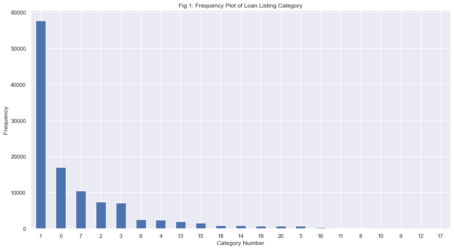

```python
# Plot to show the frequency of listing for the overall dataframe
dff.ListingCategory.value_counts().plot(kind='bar',
                                        title = 'Fig 1: Frequency Plot of Loan Listing Category',
                                        xlabel = 'Category Number',
                                        ylabel = 'Frequency',
                                        rot=0);
```

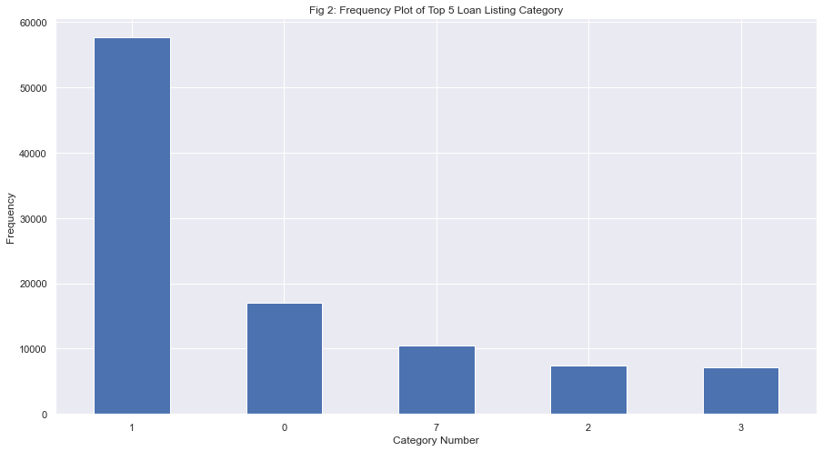

```python
# Plot to show the top 5 frequency of listing for the overall dataframe
dff.ListingCategory.value_counts()[:5].plot(kind='bar',
                                        title = 'Fig 2: Frequency Plot of Top 5 Loan Listing Category',
                                        xlabel = 'Category Number',
                                        ylabel = 'Frequency',
                                            rot=0);
```

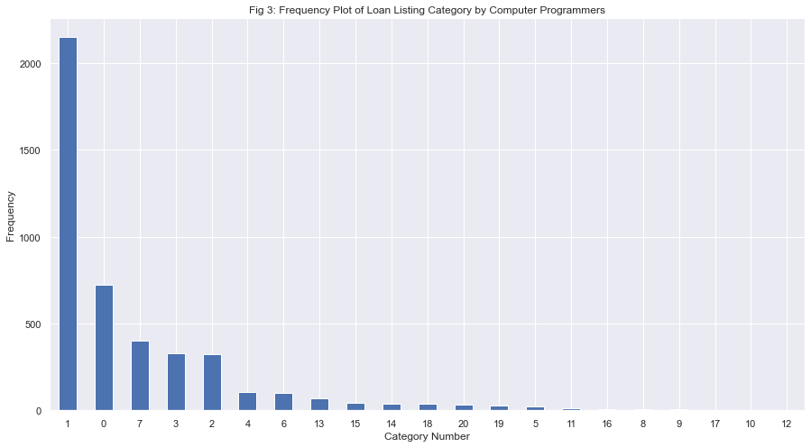

```python
# Plot to show the frequency of listing for computer programmers
occ_comp.ListingCategory.value_counts().plot(kind='bar',
                                        title = 'Fig 3: Frequency Plot of Loan Listing Category by Computer Programmers',
                                        xlabel = 'Category Number',
                                        ylabel = 'Frequency',
                                        rot=0);
```

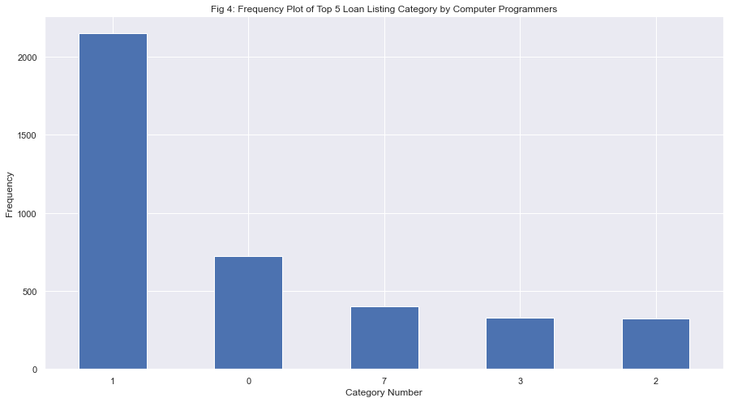

```python
# # Plot to show the top 5 frequency of listing for computer programmers
occ_comp.ListingCategory.value_counts()[:5].plot(kind='bar',
                                        title = 'Fig 4: Frequency Plot of Top 5 Loan Listing Category by Computer Programmers',
                                        xlabel = 'Category Number',
                                        ylabel = 'Frequency',rot=0);
```

#### Observation

Fig 1: The category 1 and 17 which represent; debt consolidation and RV respectively holds the position as the category with the highest and lowest count.

Fig 2: The top 5 categories that got the most funding starting from the first to the fifth are; 'debt consolidation' (1), 'not available' i.e not stated by the borrower (0), 'other' i.e borrower's option not among those available (7), 'home improvement' (2), and 'business' (3).

Fig 3: The category 1 and 12 which represent; debt consolidation and green loans respectively holds the position as the category with the highest and lowest count.

Fig 4: The top 5 categories for computer programmers that got the most funding starting from the first to the fifth are; 'debt consolidation' (1), 'not available' i.e not stated by the borrower (0), 'other' i.e borrower's option not among those available (7), 'business' (3), and 'home improvement' (2)

### Of the features you investigated, were there any unusual distributions? Did you perform any operations on the data to tidy, adjust, or change the form of the data? If so, why did you do this?

> I did a little data wrangling such as:
> - Rename ListingCategory (numeric), to ListingCategory: To aid ease of typing the column.
> - Change ListingCreationDate data type from object(string) to datatime: To make it possible to perform arithmetic and other aggregation on the datetime series.
> - Drop duplicate rows: To improve the integrity of the analysis result.
> - Fix missing values in the following columns (Occupation, DebtToIncomeRatio, GroupKey, ScorexChangeAtTimeOfListing, BorrowerState, EmploymentStatus, and EmploymentStatusDuration): To improve the tidiness of the dataframe.
> - Assign values greater than 10.00 in DebtToIncomeRatio column to 10.00: To comply with the appropriate threshold for the column values.

## Bivariate Exploration

#### Question

Is there any correlation between their loan category and loan Status? - (ListingCategory, loanStatus)

First, let's get an overview of the correlation relationships that exist in this dataframe.

#### Visualization

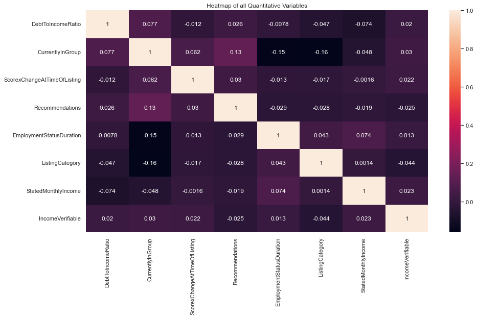

```python
# plot heatmap
sb.heatmap(data = dff.corr(), annot = True).set(title = 'Heatmap of all Quantitative Variables');
```

Going by the correlation values printed on each cell of the plot above, having -0.16 as the highest negative value and 0.13 as the highest positive value, it is obvious that there exist no strong correlation between any pair of different variables in this dataframe.

However, I will try using other plots to confirm and see what comes up.

Next, I will create a sub-dataframe for the top 5 listing category and see if any relationship exist between any of this category and the loan status variabe. Reason for this is because I will be using a clustered barchart as both variables are categorical plus their number of unique values are above 10 which will be too much to fit into the plot display.

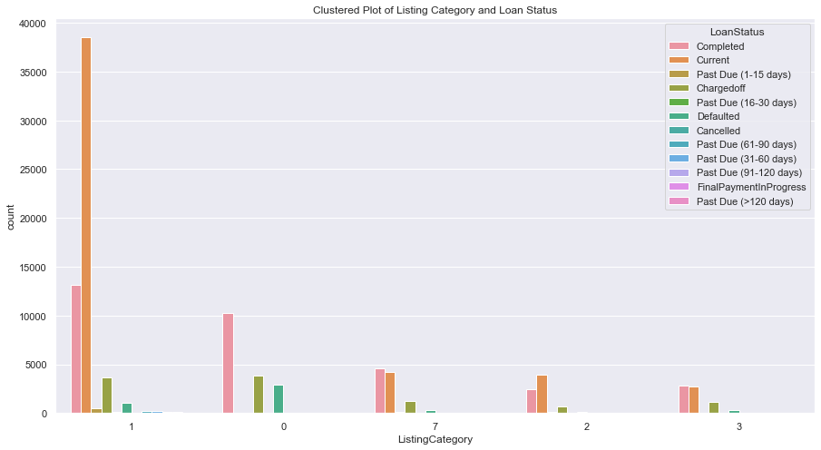

```python
# get the top 5 listing category
val = dff.ListingCategory.value_counts()[:5].index; # = [1, 0, 7, 2, 3]

# create sub-df
loanVlist = dff[
    dff['ListingCategory'].isin(val)
];

# create a clustered bar chart
sb.countplot(data = loanVlist,
             x = 'ListingCategory',
             hue = 'LoanStatus',
             order = val
            ).set(title = 'Clustered Plot of Listing Category and Loan Status');
```

Listing category number meaning

1 - Debt Consolidation

0 - Not Available,

7 - Other

2 - Home Improvement,

3 - Business

Let's see how the two top occupations compare to this visualization.

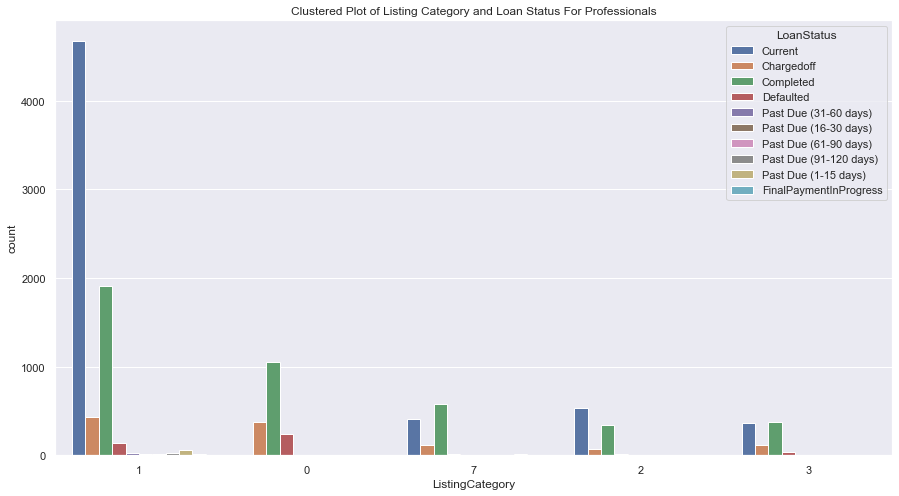

```python
# create sub-df for professionals
occ_pro = dff[ dff['Occupation'] == 'Professional'];

# get top 5 listing category
p_val = occ_pro.ListingCategory.value_counts()[:5].index # [1, 0, 7, 2, 3]

# create sub-df
p_loanVlist = occ_pro[
    occ_pro['ListingCategory'].isin(p_val)
];

# create a clustered bar chart
sb.countplot(data = p_loanVlist,
             x = 'ListingCategory',
             hue = 'LoanStatus',
             order = p_val
            ).set(title = 'Clustered Plot of Listing Category and Loan Status For Professionals');
```

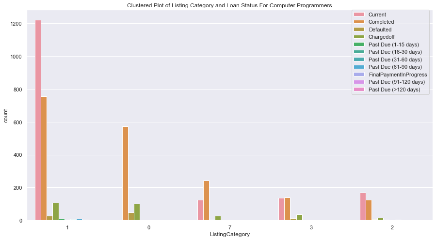

```python
# get top 5 listing category
C_val = occ_comp.ListingCategory.value_counts()[:5].index # [1, 0, 7, 3, 2]

# create sub-df
C_loanVlist = occ_comp[
    occ_comp['ListingCategory'].isin(C_val)
];

# create a clustered bar chart
sb.countplot(data = C_loanVlist,
             x = 'ListingCategory',
             hue = 'LoanStatus',
             order = C_val
            ).set(title = 'Clustered Plot of Listing Category and Loan Status For Computer Programmers');

# move legend right
plt.legend(bbox_to_anchor=(.8, 1), loc=2, borderaxespad=0.);
```

Most computer programmers were indebted, those who borrowed for business were able to complete their payment. Those who defaulted were relatively few.

#### Observations

The visualizations thus far indicate that most persons who took loan did it to consolidate on a debt. Most computer programmers were able to meet up and complete their loan repayment on time particularly those whose listing categories were not indicated.

#### Question

Was there any correlation between the borrower's DTI ratio and loan status?

#### Visualizations

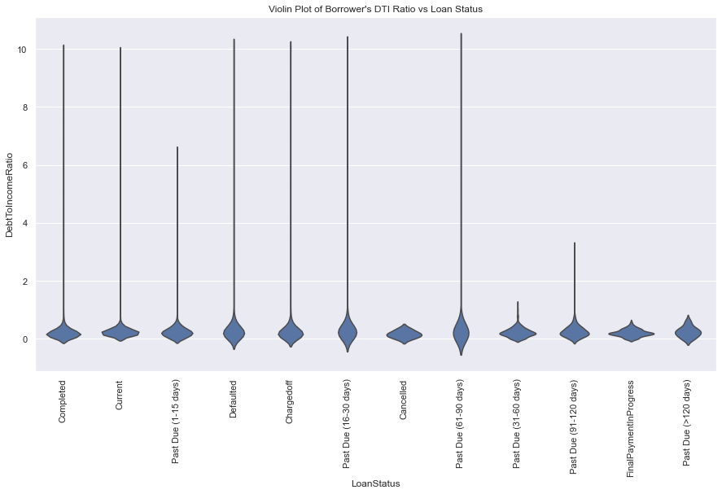

```python
# choose seaborn color palette
my_color = sb.color_palette()[0]

# make violin plot
sb.violinplot(data=dff,
              x='LoanStatus',
              y='DebtToIncomeRatio',
              inner=None,
              color = my_color).set(title = 'Violin Plot of Borrower\'s DTI Ratio vs Loan Status');
plt.xticks(rotation=90);
```

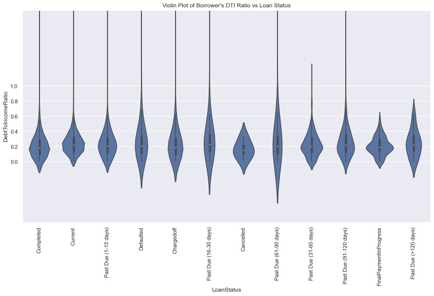

```python
# since the y-axis values just displays a long tip after 2, I set xtick values less than 2 for more detail
# make violin plot
sb.violinplot(data=dff,
              x='LoanStatus',
              y='DebtToIncomeRatio',
              color = my_color).set(title = 'Violin Plot of Borrower\'s DTI Ratio vs Loan Status');
plt.xticks(rotation=90);
plt.ylim((-0.8,2));
plt.yticks([0,0.2,0.4,0.6,0.8,1]);
```

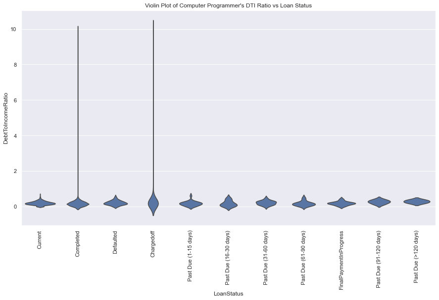

```python
# create violin plot
sb.violinplot(data=occ_comp,
              x='LoanStatus',
              y='DebtToIncomeRatio',
              inner=None,
              color = my_color).set(title = 'Violin Plot of Computer Programmer\'s DTI Ratio vs Loan Status');
plt.xticks(rotation=90);
```

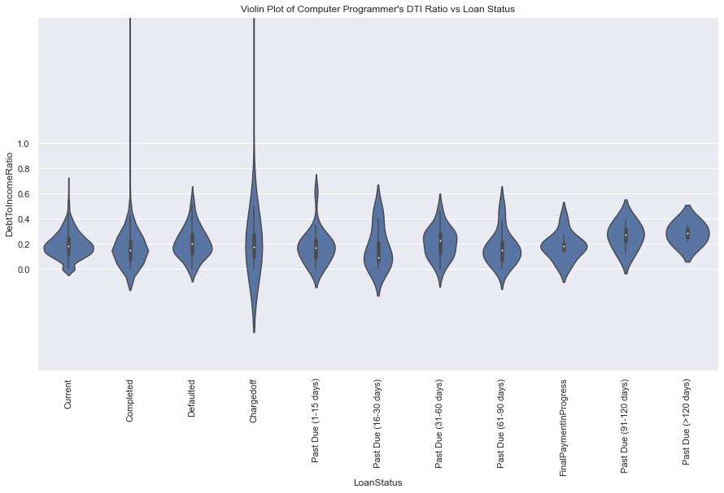

```python
sb.violinplot(data=occ_comp,
              x='LoanStatus',
              y='DebtToIncomeRatio',
              #inner='quartile',
              color = my_color).set(title = 'Violin Plot of Computer Programmer\'s DTI Ratio vs Loan Status');
plt.xticks(rotation=90);
plt.ylim((-0.8,2));
plt.yticks([0,0.2,0.4,0.6,0.8,1]);
```

#### Observations

For computer programmers, those with the lowest DTI median ratio were past their due date by 16-30 days, while those with the highest median ratio were behind by at least 120 days. Having a DTI ratio below 0.2 seem to be a good score associated with good borrower's.

#### Question

Was there a correlation between borrower's employment status and loan status?

Since both variables contain qualitative values, I will use a clustered bar chart for this visualization

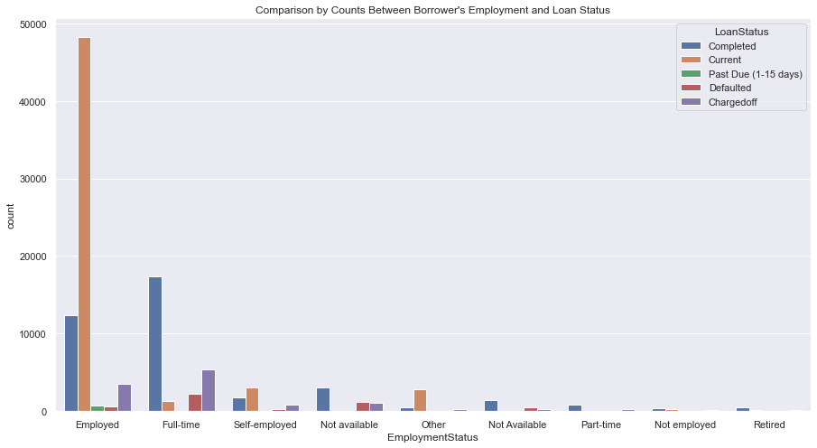

```python
# create sub-df for top loan status
top_loan_stat = dff[
    (dff['LoanStatus'] == 'Current') |
    (dff['LoanStatus'] == 'Completed') |
    (dff['LoanStatus'] == 'Chargedoff') |
    (dff['LoanStatus'] == 'Defaulted') |
    (dff['LoanStatus'] == 'Past Due (1-15 days)')
]

# variable to contain sorted order of employment status
count = dff.EmploymentStatus.value_counts().index

# create a clustered bar chart
sb.countplot(data = top_loan_stat,
             x = 'EmploymentStatus',
             hue = 'LoanStatus',
             order = count
            ).set(title = 'Comparison by Counts Between Borrower\'s Employment and Loan Status');
```

[figure not shown]

```python
# create sub-df for professionals
pro_Lstat = top_loan_stat[top_loan_stat['Occupation'] == 'Professional']

# variable to contain sorted order of employment status
P_count = pro_Lstat.EmploymentStatus.value_counts().index

# create a clustered bar chart
sb.countplot(data = pro_Lstat,
             x = 'EmploymentStatus',
             hue = 'LoanStatus',
             order = count
            ).set(title = 'Comparison by Counts Between Computer Programmer\'s Employment and Loan Status');

# move legend right
plt.legend(bbox_to_anchor=(.8, 1), loc=2, borderaxespad=0.);
```

#### Observations

Surprisingly, those who were employed took the most loan with the majority currently servicing their loan well. However, those who were employed on full-time basis seem to have the most completed loan status with no past due date within 1-15 days. They however, have the highest number of defaulted and chargedoff status.

### Did you observe any interesting relationships between the other features (not the main feature(s) of interest)?

> Although, I already trimmed the data set to focus on variables of interest. I observed that there exist no strong correlation between any pair of different variables in the 'dff' dataframe.